# Sampling

January 2020

## Why sampling?

- In most cases a complete enumeration is not possible, but if done properly, proporties of a population can be inferred from a randomly selected sample

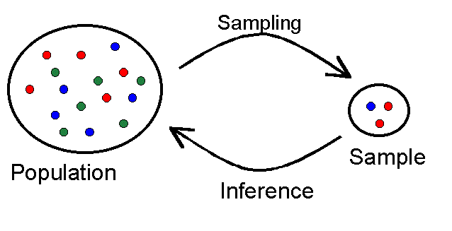

## General approach

- Overall planning of the survey
- Define the population of interest
- Constructing the sampling frame
- Choice of sampling design
- Selection of sample
- Data collection
- Data editing and imputation
- Estimation
- Dissemination

## Sampling error

- The fact that not all units go into the inference introduces an uncertainty about the estimates which we call **sampling error**
- The sampling error is a consequence of the fact that we would get (slightly) different results if we could **repeatedly draw** new samples
- Given a sampling design the sampling error will generally be lower if the units in the population are alike (**low variance**) or the sample size is bigger
- **Note:** For the same sample size the sampling error will be smaller if a suitable design is chosen

## Simple demonstration of sampling error

```r
# synthetic population
set.seed(236542)
N <- 1000
yi <- rnorm(N, mean=5000, s=1000)

# attributes at population level
mean (yi)
```

```
## [1] 4965.94
```

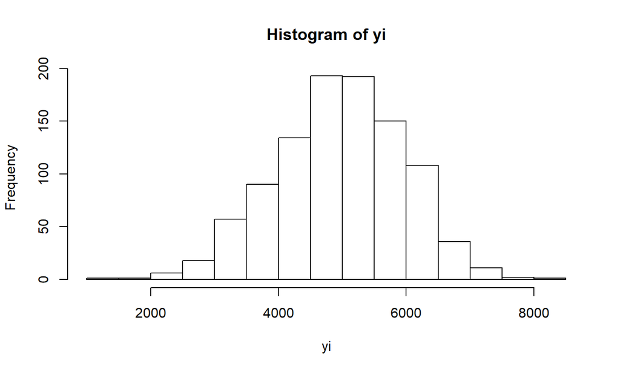

```r
hist (yi)
```

```r
# take a sample of size n
n <- 10
s <- sample(1:length(yi), n, replace = FALSE)

# mean of sample
mean(yi[s])
```

```
## [1] 4729.023
```

```r
mean(yi)
```

```
## [1] 4965.94
```

```r
# repeat sampling K times
K <- 1000
mu_hat <- numeric(K)

for (i in 1:K){
  s <- sample(1:length(yi), n, replace = FALSE)
  mu_hat[i] <- mean(yi[s])
}

mean(mu_hat)
```

```
## [1] 4964.755
```

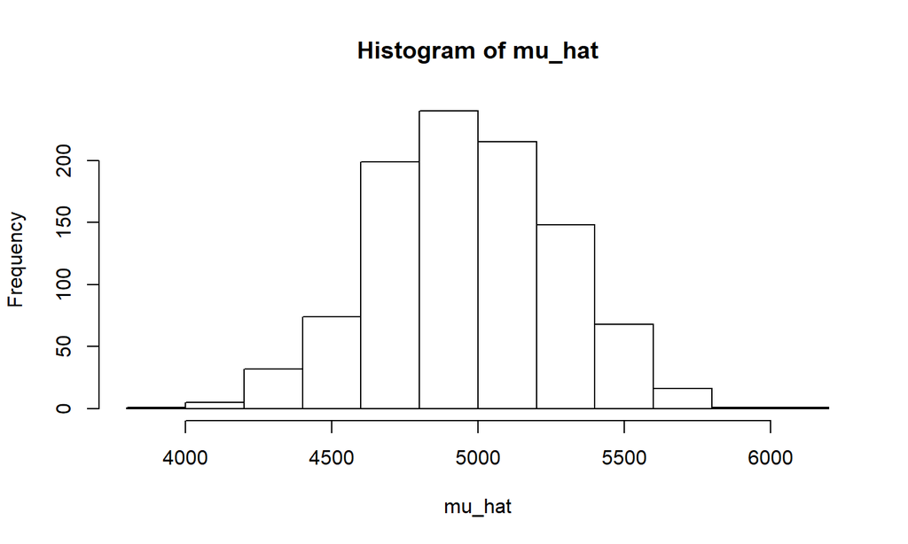

```r
# sampling distribution
hist(mu_hat)
```

## Representativity

- Representativity is **not** dependent upon the sample size
- For a sample to be representative, **all** units must have the **possibily** to be in the sample (inclusion probability > 0)
- The intuitive meaning of a **representative** sample normally is that has a certain size, but also that the marginal proporties of the sample resemble those of the population
  - Certain procedures exist that makes a **balanced sample** in exactly this meaning
  - A balanced sample is also said to be **well spread** and actual measures for this have been constructed (see eg. Grafström og Tillé)

## SRS: Simple random sampling

- SRS is one of the fundamental building blocks
- Assume a population of size \(N\) and that a sampling frame (a list of units) is available
- Randomly select \(n\) out of \(N\) units without replacement
- The implied inclusion probability is \(\pi = n/N\)
- Note: This is **equivalent** to considering the \(C(N,n)\) possible \(n\)-subsets and randomly select one of these as the sample!

## SSRS, Stratified Simple Random Sampling

- A **stratification** is a subdivision of the population into different groups, called **strata**
- Stratification allows for **different inclusion probabilities**, e.g. more large companies or more units that we know are unlikely to respond
- In stratified simple random sampling with \(H\) strata, the strata are usually written as \(N_h, h = 1, \dots, H\), the number of units in each stratum is \(n_h\), and their inclusion probabilities are \(\pi_h = \frac{n_h}{N_h}\)

## Stratification variables

- There is no right or wrong stratification, but a good stratification can decrease variance significantly
- Stratification variables are the variables used to divide the population into subgroups
- consider this population

```r
load(file = "mydata_example.Rda")
head(mydata_example[, 1:6], n=5)
```

```
##       name region   sector Nr_empl_reg turnover_2019 turnover_2020
## 1  bdbdaab   EAST Services         157        641778        636503
## 6  girgcbf  NORTH Services         223       1173893       1221045
## 11 lnewjfe   WEST Services         205        826874        800375
## 16 qsczlmm   WEST Services         378       1803952       1945828
## 21 vxuzetc  NORTH Services         208        912342        959651
```

A stratification by region and sector would look like this:

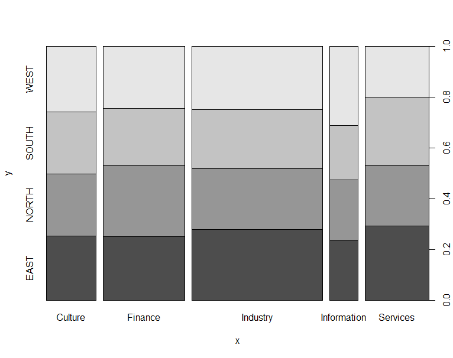

## A Note on choice of Stratification

- A stratification might get too fine grained, i.e. there’s not enough sample units to get a sufficient amount of units in each stratum
- There’s no official, minimal sample size per stratum, but we recommend at least 10 units
- If your stratification doesn’t allow for that, choose a larger sample size or a coarser stratification
- (A coarser stratification means less strata)

## Allocation

- Allocation is the distribution of a sample of size \(n\) across the \(H\) strata
- Allocating a sample and drawing a sample is not the same thing
- There’s no right or wrong allocation, but we would try to allocate units in order to best meet the objectives in the survey design, e.g. allocate according to (known or expected) response propensities, or in order to cover 70 % of the turnover of the companies in each sector
- A well-chosen sample allocation together with a well-chosen stratification can minimise the uncertainty or sampling error significantly

## Some Allocation Methods

- There are several ways of allocating a sample:
  - Proportional Allocation, in which we allocate the sample units proportionally to stratum size, or to the proportion of some measure of interest in each stratum, e.g. number of employees
  - Weighted proportional allocation, in which we use a weighted sum of allocations proportional to various variables of interest
  - Optimal or Neyman allocation, in which we allocate sample units according to the variation of a variable of interest in each stratum, so that we allocate more sample units in strata with more variation

## Allocation Formulas

- Proportional Allocation is computed by this formula:

  \(n_h = n \cdot \frac{N_h}{\sum_{h = 1}^H N_h}\),

where \(H\) is the number if strata, \(n\) is the sample size, and \(N_h\) is the size of stratum \(h\) (either in population units or in terms of some other measurement)

- Optimal or Neyman Allocation is computed by this formula:

  \(n_h = n \cdot \frac{N_h s_h}{\sum_{h = 1}^H N_h s_h}\),

where \(s_h\) is the standard error in stratum \(h\) of a variable of interest

## Definitions and Corrections

- Our sampling method may allocate more units than \(N_h\) or may allocate \(n_h < 10\). In that case, some corrections are necessary.
- Strata in which we allocate no units (e.g. because the units in those strata are “small” in the sense that they are below some bagatel threshold, e.g. 10 employees or turnover below 50,000) are called **take none**
- Strata in which we allocate some but not all units are called *take some*
- Strata in which we allocate all units (e.g. because the strata are small or because the units are “large” or “important” in some sense) are called **take all*
- Using the **samplingbook** package written by Juliane Manitz and others will give us a lot of functionality automatically

```r
library(samplingbook)
```

- In order to use our stratification, we first have to create a variable counting the strata

```r
load(file = "mydata_example.Rda")

Strata <- unique (mydata_example[,c("sector", "region")])
Strata <- Strata[order(Strata$sector, Strata$region),]
rownames(Strata) <- NULL
Strata$stratum <- 1:dim(Strata)[1]
Strata <- Strata[c(3,1,2)]
head(Strata, n = 5)
```

```
##   stratum  sector region
## 1       1 Culture   EAST
## 2       2 Culture  NORTH
## 3       3 Culture  SOUTH
## 4       4 Culture   WEST
## 5       5 Finance   EAST
```

## Then we merge it onto our dataframe

```r
mydata_example <- merge (mydata_example, Strata,
                          by=c("sector", "region"))
mydata_example[c(1,72,140,210,281,396,525,630,741,949),]
```

```
##       sector region    name Nr_empl_reg turnover_2019 turnover_2020
## 1    Culture   EAST vrnvutz          79        344953        361419
## 72   Culture  NORTH ldsboar         107        799434        840052
## 140  Culture  SOUTH vlhwtxx          87        712134        760225
## 210  Culture   WEST djozuhg          82        441370        422447
## 281  Finance   EAST hdzplwj         104        370258        360745
## 396  Finance  NORTH owebnac          57        336997        356333
## 525  Finance  SOUTH gqgewzf          53        374248        403879
## 630  Finance   WEST wuyacod         266       1392880       1331994
## 741 Industry   EAST ltcwgsc         404       2894617       2712014
## 949 Industry  NORTH djrylxq         106        525053        523901
##     Nr_empl_2020 stratum
## 1             75       1
## 72           144       2
## 140          115       3
## 210           89       4
## 281           97       5
## 396           78       6
## 525           67       7
## 630          250       8
## 741          515       9
## 949          117      10
```

Allocating a Proportional Sample

- We now want two summary statistics on stratum level: Size of each stratum (Nh) and standard deviation of last years turnover (sh)
- We calculate the size of each stratum and also the standard deviation of last years turnover (we do not need this for proportional allocation, but we’ll need it for Neyman allocation later on)

```r
Nh <- aggregate (mydata_example$stratum,
                 list(stratum=mydata_example$stratum),
                 length)
names(Nh)[2] <- "Nh"

sh <- aggregate (mydata_example$turnover_2019,
                 list(stratum=mydata_example$stratum),
                 sd, na.rm=TRUE)
names(sh)[2] <- "sh"

Strata <- merge(Strata, Nh, by="stratum")
Strata <- merge(Strata, sh, by="stratum")
```

```
##    stratum      sector region  Nh        sh
## 1        1     Culture   EAST  71  283598.2
## 2        2     Culture  NORTH  68  296821.2
## 3        3     Culture  SOUTH  69  296387.4
## 4        4     Culture   WEST  72  276698.5
## 5        5     Finance   EAST 115  284475.2
## 6        6     Finance  NORTH 129  265058.5
## 7        7     Finance  SOUTH 104  265086.1
## 8        8     Finance   WEST 112  292366.1
## 9        9    Industry   EAST 206 1800975.9
## 10      10    Industry  NORTH 178 1813788.1
## 11      11    Industry  SOUTH 172 1891169.0
## 12      12    Industry   WEST 184 1811919.1
## 13      13 Information   EAST  38  159326.8
## 14      14 Information  NORTH  38  108223.9
## 15      15 Information  SOUTH  34  216443.7
## 16      16 Information   WEST  50  151461.9
## 17      17    Services   EAST 105  333420.6
## 18      18    Services  NORTH  86  367843.0
## 19      19    Services  SOUTH  97  341406.7
## 20      20    Services   WEST  72  339095.3
```

- We can now use the function **stratasamp** from the samplingbook package in order to allocate a sample.

  **stratasamp(n, Nh, Sh = NULL, Ch = Null, type = ‘prop’)**,

  where **n** is sample size, **Nh** is stratum size, **Sh** is stratum stabdard error, **Ch** is cost (which we will not look into here) and **type** is the allocation method, which defaults to ‘prop’ = proportional.
- Note that the sample allocation takes place in the dataframe **Strata**, not in the dataframe that we want to draw the sample from.

```r
n <- 1000
alloc1 <- stratasamp (n, Nh=Strata$Nh)
```

```r
alloc1
```

```
##
## Stratum  1  2  3  4  5  6  7  8   9 10 11 12 13 14 15 16 17 18 19 20
## Size    36 34 34 36 58 64 52 56 103 89 86 92 19 19 17 25 52 43 48 36
```

Adding alloc1 to the sample data frame:

```r
Strata$nh_prop <- alloc1[2,]
Strata$f_prop <- Strata$nh_prop/Strata$Nh
```

## Allocation a Neyman Sample

- Notice that type is set to ‘opt’, as Neyman allocation goes by the name of optimal allocation, too.

```r
n <- 1000
alloc2 <- stratasamp (n, Nh=Strata$Nh, Sh=Strata$sh, type="opt")
```

```r
alloc2
```

```
##
## Stratum  1  2  3  4  5  6  7  8   9  10  11  12 13 14 15 16 17 18 19 20
## Size    12 12 12 12 19 20 16 19 217 189 190 195  4  2  4  4 20 19 19 14
```

However, the allocation procedure doesn’t take stratum size into consideration:

```r
Strata$nh <- alloc2[2,]
impossible_allocation <- (Strata$nh > Strata$Nh)
impossible_allocation
```

```
##  [1] FALSE FALSE FALSE FALSE FALSE FALSE FALSE FALSE  TRUE  TRUE  TRUE  TRUE
## [13] FALSE FALSE FALSE FALSE FALSE FALSE FALSE FALSE
```

- We can add the TRUEs together, and then we get:

```r
sum (impossible_allocation)
```

```
## [1] 4
```

That is, there are 4 strata in which we have allocated more units than there are in the stratum. Luckily, this can be fixed.

At first, we make the offending strata into take all strata (utilising that TRUE acts as the value 1):

```r
Strata$nh[impossible_allocation] <- Strata$Nh[impossible_allocation]
Strata$nh[!impossible_allocation] <- NA
```

And the remaining sample is allocated using the same function

```r
n_rem <- n - sum(Strata$nh, na.rm=TRUE)
s <- Strata [!impossible_allocation, ]
alloc2.2 <- stratasamp (n_rem, Nh=s$Nh, Sh=s$sh)
alloc2.2
```

```
##
## Stratum  1  2  3  4  5  6  7  8 9 10 11 12 13 14 15 16
## Size    15 14 14 15 24 27 21 23 8  8  7 10 22 18 20 15
```

Putting allocation and Strata data frame back together, we get:

```r
s$nh <- alloc2.2[2,]
Strata <- rbind (Strata[impossible_allocation,], s)
sum (Strata$nh)
```

```
## [1] 1001
```

We can adjust a bit more to adhere to the “at least 10 units”-rule, and then we get:

```r
Strata$nh[Strata$nh < 10] <- 10
Strata <- Strata[order(Strata$stratum),]
Strata$f <- Strata$nh / Strata$Nh
sum(Strata$nh)
```

```
## [1] 1008
```

We now have two different allocations:

```r
Allocs <- Strata[, c(1,4,6,7,8,9)]
```

```
##    stratum  Nh nh_prop    f_prop  nh         f
## 1        1  71      36 0.5070423  15 0.2112676
## 2        2  68      34 0.5000000  14 0.2058824
## 3        3  69      34 0.4927536  14 0.2028986
## 4        4  72      36 0.5000000  15 0.2083333
## 5        5 115      58 0.5043478  24 0.2086957
## 6        6 129      64 0.4961240  27 0.2093023
## 7        7 104      52 0.5000000  21 0.2019231
## 8        8 112      56 0.5000000  23 0.2053571
## 9        9 206     103 0.5000000 206 1.0000000
## 10      10 178      89 0.5000000 178 1.0000000
## 11      11 172      86 0.5000000 172 1.0000000
## 12      12 184      92 0.5000000 184 1.0000000
## 13      13  38      19 0.5000000  10 0.2631579
## 14      14  38      19 0.5000000  10 0.2631579
## 15      15  34      17 0.5000000  10 0.2941176
## 16      16  50      25 0.5000000  10 0.2000000
## 17      17 105      52 0.4952381  22 0.2095238
## 18      18  86      43 0.5000000  18 0.2093023
## 19      19  97      48 0.4948454  20 0.2061856
## 20      20  72      36 0.5000000  15 0.2083333
```

## Drawing a Stratified, Simple Random Sample

Now it is easy to select the sample:

```r
library (sampling)
mydata_example <- mydata_example[order(mydata_example$stratum),]

s_prop <- sampling::strata (mydata_example,
                       stratanames="stratum",
                       size=Strata$nh_prop,
                       method="srswor")

s_opt <- sampling::strata (mydata_example,
                       stratanames="stratum",
                       size=Strata$nh,
                       method="srswor")
```

Finally extract the samples and save them:

```r
mysample_prop <- getdata (mydata_example, s_prop)
mysample_opt <- getdata (mydata_example, s_opt)

save (mysample_prop, file="mysample_prop.Rda")
save (mysample_opt, file="mysample_opt.Rda")
```

## A Brief Note on PPS Sampling

- The strata-function has the following options:

  **strata(data, stratnames = NULL, size, method = c(“srswor”, “srswr”, “poisson”, “systematic”), pik, description = FALSE)**
- Using the poisson option and calculating the inclusion probabilities cleverly can be used to get PPS sampling
- Either aggregate the function *inclusionprobabilities(interest_variable, n_h)* over each stratum, which will calculate the PPS inclusion probabilities of each unit in that stratum (interest_variable might be turnover or number of employees), or
- Alternatively just providing **interest_variable** as **pik** (which will then call inclusionprobabilities)
- And selecting the option **“poisson”** when drawing the sample
- Gives PPS Sample
- We use PPS sampling in very few statistics at Statistics Denmark. If you want to have a lot of large units according to some measure, you can put them in a take all-stratum with \(n_h = N_h\) or with \(f \sim 1\)